# Moneyball Project

This is a project from an R Data Science course I completed on DataCamp. This project involves a problem faced in 2002 by the Oakland A's. Following the 2001 season, the team lost three key players. The front office took advantage of new baseball stastics to replace the lost players with cheaper ones to win 20 consecutive games. The story became the premise of Michael Lewis' 2003 book Moneyball: The Art of Winning an Unfair Game. This project is based off the book written by Michael Lewis (later turned into a movie staring Brad Pitt).

*Data from Sean Lahman:* http://www.seanlahman.com/baseball-archive/statistics/  
Batting and Salaries tables are used for this project

#### Goal Of This Project

Using these three metrics, replace 3 lost players with comparable stats and cheaper salaries

Batting Average (BA): Hits/AtBat  
On Base Percentage (OBP): (Hits + BasesOnBalls + HitByPitch)/(AtBat + BasesOnBalls + HitByPitch + SacrificeFly)  
Slugging Percentage (SLG): ('1B' + (2*'2B') + (3*'3B0') + (4*HomeRuns)) / AtBat

**The players lost were**  
first baseman 2000 AL MVP Jason Giambi (giambja01)  
outfielder Johnny Damon (damonjo01)  
infielder Rainer Gustavo "Ray" Olmedo (saenzol01)

```r
## load libraries and data
library(tidyverse)

Batting <- read_csv("Batting.csv")
Salaries <- read_csv("Salaries.csv")
```

#### Data Wrangling and Exploration

```r
## Look at Batting dataframe
head(Batting)

# Calculate BA, OBP, and SLG batting meterics. Singles = (H-HR-3B-2B)
BattingNew <- Batting %>%
  mutate(BA = H/AB,
         OBP = (H + BB + HBP)/(AB + BB + HBP + SF),
         SLG = ((H-HR-X3B-X2B) + (2*X2B) + (3*X3B) + (4*HR))/AB
         )
```

| playerID | yearID | stint | teamID | lgID | G | G_batting | AB | R | H | ... | SB | CS | BB | SO | IBB | HBP | SH | SF | GIDP | G_old |
| --- | --- | --- | --- | --- | --- | --- | --- | --- | --- | --- | --- | --- | --- | --- | --- | --- | --- | --- | --- | --- |
| aardsda01 | 2004 | 1 | SFN | NL | 11 | 11 | 0 | 0 | 0 | ... | 0 | 0 | 0 | 0 | 0 | 0 | 0 | 0 | 0 | 11 |
| aardsda01 | 2006 | 1 | CHN | NL | 45 | 43 | 2 | 0 | 0 | ... | 0 | 0 | 0 | 0 | 0 | 0 | 1 | 0 | 0 | 45 |
| aardsda01 | 2007 | 1 | CHA | AL | 25 | 2 | 0 | 0 | 0 | ... | 0 | 0 | 0 | 0 | 0 | 0 | 0 | 0 | 0 | 2 |
| aardsda01 | 2008 | 1 | BOS | AL | 47 | 5 | 1 | 0 | 0 | ... | 0 | 0 | 0 | 1 | 0 | 0 | 0 | 0 | 0 | 5 |
| aardsda01 | 2009 | 1 | SEA | AL | 73 | 3 | 0 | 0 | 0 | ... | 0 | 0 | 0 | 0 | 0 | 0 | 0 | 0 | 0 | NA |
| aardsda01 | 2010 | 1 | SEA | AL | 53 | 4 | 0 | 0 | 0 | ... | 0 | 0 | 0 | 0 | 0 | 0 | 0 | 0 | 0 | NA |

```r
# Check new df
head(BattingNew)

## Look at Salaries df
head(Salaries)
```

| playerID | yearID | stint | teamID | lgID | G | G_batting | AB | R | H | ... | SO | IBB | HBP | SH | SF | GIDP | G_old | BA | OBP | SLG |
| --- | --- | --- | --- | --- | --- | --- | --- | --- | --- | --- | --- | --- | --- | --- | --- | --- | --- | --- | --- | --- |
| aardsda01 | 2004 | 1 | SFN | NL | 11 | 11 | 0 | 0 | 0 | ... | 0 | 0 | 0 | 0 | 0 | 0 | 11 | NaN | NaN | NaN |
| aardsda01 | 2006 | 1 | CHN | NL | 45 | 43 | 2 | 0 | 0 | ... | 0 | 0 | 0 | 1 | 0 | 0 | 45 | 0 | 0 | 0 |
| aardsda01 | 2007 | 1 | CHA | AL | 25 | 2 | 0 | 0 | 0 | ... | 0 | 0 | 0 | 0 | 0 | 0 | 2 | NaN | NaN | NaN |
| aardsda01 | 2008 | 1 | BOS | AL | 47 | 5 | 1 | 0 | 0 | ... | 1 | 0 | 0 | 0 | 0 | 0 | 5 | 0 | 0 | 0 |
| aardsda01 | 2009 | 1 | SEA | AL | 73 | 3 | 0 | 0 | 0 | ... | 0 | 0 | 0 | 0 | 0 | 0 | NA | NaN | NaN | NaN |
| aardsda01 | 2010 | 1 | SEA | AL | 53 | 4 | 0 | 0 | 0 | ... | 0 | 0 | 0 | 0 | 0 | 0 | NA | NaN | NaN | NaN |

| yearID | teamID | lgID | playerID | salary |
| --- | --- | --- | --- | --- |
| 1985 | BAL | AL | murraed02 | 1472819 |
| 1985 | BAL | AL | lynnfr01 | 1090000 |
| 1985 | BAL | AL | ripkeca01 | 800000 |
| 1985 | BAL | AL | lacyle01 | 725000 |
| 1985 | BAL | AL | flanami01 | 641667 |
| 1985 | BAL | AL | boddimi01 | 625000 |

```r
## Add salary to Batting df. Year and player are going to be the overlapping columns.
# Check year for each dataframe and chop Batting down to same timeframe as Salaries.
summary(BattingNew$yearID)
summary(Salaries$yearID)

BattingChopped <- BattingNew %>%
  filter(yearID >= 1985)

summary(BattingChopped$yearID)

BattingMerged <- merge(BattingChopped, Salaries, by = c('playerID','yearID'))

## Look at stats for three lost players (giambja01, damonjo01, saenzol01)
LostBoys <- BattingMerged %>%
  filter(playerID == 'giambja01' | playerID == 'damonjo01' | playerID == 'saenzol01')

# Filter for year 2001 when we want to replace them, get H,2B,3B,HR,OBP,SLG,BA,AB,salary stats only
LostBoysSubset <- LostBoys %>%
  filter(yearID == 2001) %>%
  select(playerID, H, X2B, X3B, HR, OBP, SLG, BA, AB, salary)

LostBoysSubset

## Find list of players to replace the three 'Lost Boys'
# salary of three new cannot > 15 million
# combined AB >= combined lost players
# mean OBP >= mean OBP of lost players

sum(LostBoysSubset$salary) # $11,493,333
sum(LostBoysSubset$AB) # 1469
mean(LostBoysSubset$OBP) # 0.3638687

## Chop dataset to 2001 and the same stats
BattingMergedChopped <- BattingMerged %>%
  filter(yearID == 2001) %>%
  select(playerID, H, X2B, X3B, HR, OBP, SLG, BA, AB, salary)

#unique(BattingMergedChopped$playerID) #817 players in list
```

```
   Min. 1st Qu.  Median    Mean 3rd Qu.    Max.
   1871    1931    1970    1962    1995    2013
```

```
   Min. 1st Qu.  Median    Mean 3rd Qu.    Max.
   1985    1993    1999    1999    2006    2013
```

```
   Min. 1st Qu.  Median    Mean 3rd Qu.    Max.
   1985    1993    2000    2000    2007    2013
```

| playerID | H | X2B | X3B | HR | OBP | SLG | BA | AB | salary |
| --- | --- | --- | --- | --- | --- | --- | --- | --- | --- |
| damonjo01 | 165 | 34 | 4 | 9 | 0.3235294 | 0.3633540 | 0.2562112 | 644 | 7100000 |
| giambja01 | 178 | 47 | 2 | 38 | 0.4769001 | 0.6596154 | 0.3423077 | 520 | 4103333 |
| saenzol01 | 67 | 21 | 1 | 9 | 0.2911765 | 0.3836066 | 0.2196721 | 305 | 290000 |

11493333

1469

0.363868677128079

### Make Histograms to Define Cutoffs for Poorly Performing Players

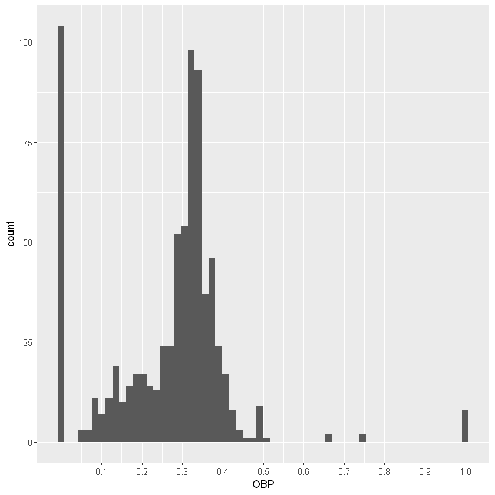

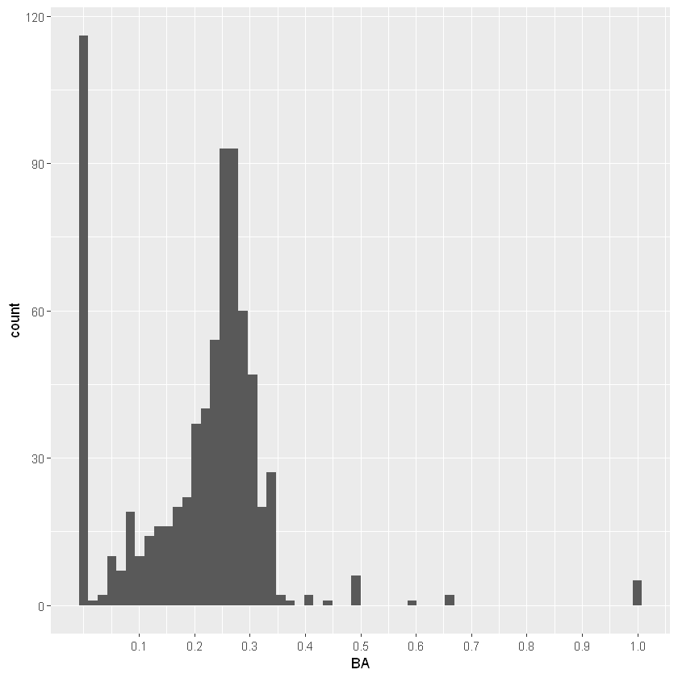

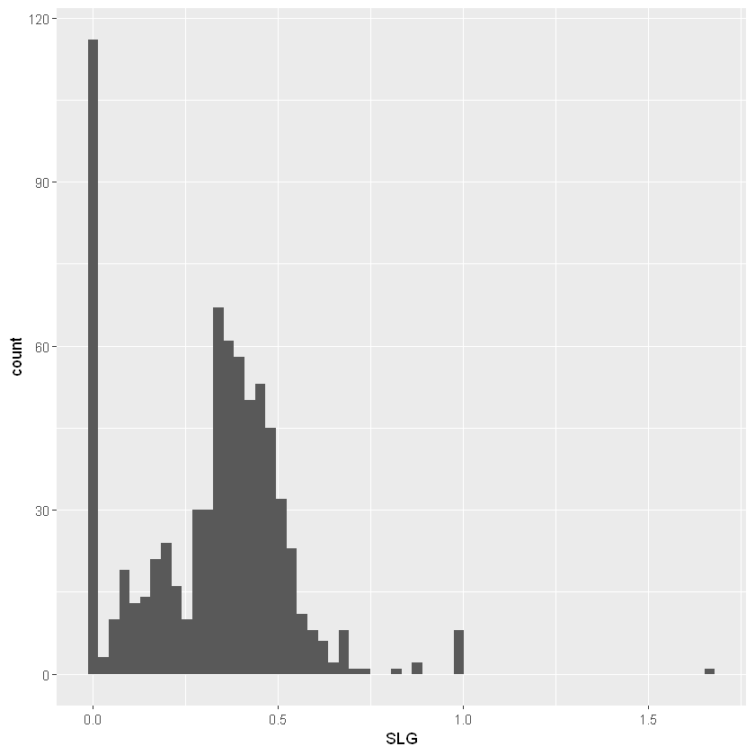

```r
## Look at the spread for OBP, BA, SLG

## OBP (.3 - .4 is good), can remove players with < 0.3
ggplot(BattingMergedChopped, aes(OBP)) + geom_histogram(bins=60) +
  scale_x_continuous(breaks = seq(0.1, 1, length = 10))

## BA (.3 is excellent), can remove players with < 0.21 based on spread
ggplot(BattingMergedChopped, aes(BA)) + geom_histogram(bins = 60) +
  scale_x_continuous(breaks = seq(0.1, 1, length = 10))

## SLG: peak is around < 0.5, maybe not best metric to filter by
ggplot(BattingMergedChopped, aes(SLG)) + geom_histogram(bins = 60)
```

```r
## Remove players based on their low OBP and low BA
BattingRmLow <- BattingMergedChopped %>%
  filter(OBP >= 0.3 & BA >= 0.21)

## Mean, median, mode for stats
mean(BattingRmLow$OBP) # 0.3622655
median(BattingRmLow$OBP) # 0.3391054

mean(BattingRmLow$BA) # 0.2942963
median(BattingRmLow$BA) # 0.27559

mean(BattingRmLow$SLG) # 0.4604938
median(BattingRmLow$SLG) # 0.4388026
```

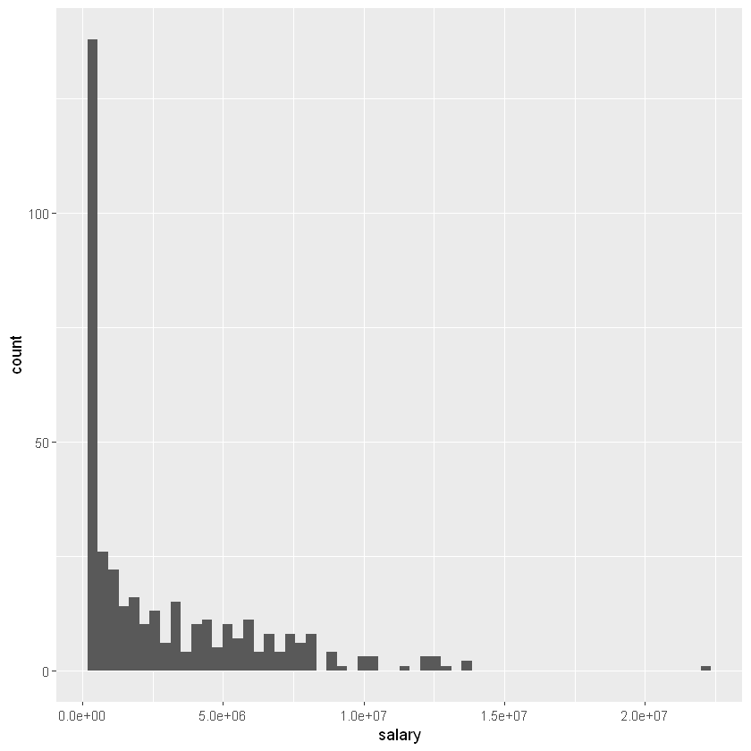

```r
## Look at spread of salary
ggplot(BattingRmLow, aes(salary)) + geom_histogram(bins = 60)
```

```r
## Find cheapest players in the 3rd quartile for OBP and BA
summary(BattingRmLow$OBP) #0.37
summary(BattingRmLow$BA) #0.30

## Filter players in 3rd Quartile for OBP and BA. Chopped down to 69 top players
Players3Q <- BattingRmLow %>%
  filter(OBP >= 0.37 & BA >= 0.30)

## Sort by highest OBP, BA, and cheapest salary. Noticed a lot of low AB values.
Players3Q <- Players3Q %>%
  arrange(desc(OBP), desc(BA), salary)
```

```
   Min. 1st Qu.  Median    Mean 3rd Qu.    Max.
 0.3000  0.3229  0.3391  0.3623  0.3713  1.0000
```

```
   Min. 1st Qu.  Median    Mean 3rd Qu.    Max.
 0.2105  0.2565  0.2756  0.2943  0.3025  1.0000
```

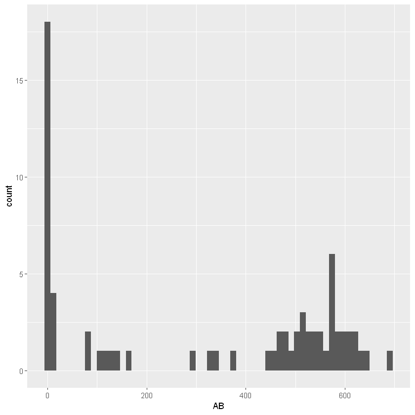

```r
## Filter out low At Bats

ggplot(Players3Q, aes(AB)) + geom_histogram(bins = 60)
## Spread a bit, over 400 looks like a good cutoff
```

```r
## PlayersHighAB now has 36 players
PlayersHighAB <- Players3Q %>%
  filter(AB > 400)

## Check out spread for player stats
summary(PlayersHighAB)
## H: 141-242, HR: 2-73, OBP: 0.37-0.51, SLG: 0.41-0.86, BA: 0.3-0.35

## Sort again by lowest salary, highest OBP, highest SLG.
PlayersHighAB <- PlayersHighAB %>%
  arrange(salary, desc(OBP), desc(SLG))
```

```
   playerID               H              X2B             X3B
 Length:36          Min.   :141.0   Min.   :23.00   Min.   : 0.000
 Class :character   1st Qu.:161.5   1st Qu.:32.00   1st Qu.: 1.000
 Mode  :character   Median :175.0   Median :35.00   Median : 2.000
                    Mean   :176.7   Mean   :36.75   Mean   : 3.278
                    3rd Qu.:191.5   3rd Qu.:40.00   3rd Qu.: 5.000
                    Max.   :242.0   Max.   :55.00   Max.   :12.000
       HR             OBP              SLG               BA
 Min.   : 2.00   Min.   :0.3705   Min.   :0.4149   Min.   :0.3002
 1st Qu.:20.75   1st Qu.:0.3806   1st Qu.:0.5142   1st Qu.:0.3070
 Median :31.00   Median :0.3954   Median :0.5650   Median :0.3176
 Mean   :31.19   Mean   :0.4033   Mean   :0.5690   Mean   :0.3196
 3rd Qu.:38.00   3rd Qu.:0.4190   3rd Qu.:0.6091   3rd Qu.:0.3304
 Max.   :73.00   Max.   :0.5151   Max.   :0.8634   Max.   :0.3501
       AB            salary
 Min.   :449.0   Min.   :  200000
 1st Qu.:510.5   1st Qu.: 2420833
 Median :557.0   Median : 5375000
 Mean   :552.6   Mean   : 6187183
 3rd Qu.:590.8   3rd Qu.:10012500
 Max.   :692.0   Max.   :22000000
```

### Solutions!

The goal is three replacement players with: sum(AB) >= 1469 & mean(OBP) >= 0.3638687 & salary < 15000000

```r
### TWO SOLUTIONS, but many combos on the list of 36 would work.

# One high salary player (28 row: bondsba01 or row 29: jonesch06)
# 2 low salary players (1: pujolal01, 2: mientdo01, or any 2 from row 4 up)
sum(PlayersHighAB[1:2,]$AB, PlayersHighAB[28,]$AB) # 1609
mean(PlayersHighAB[1:2,]$OBP, PlayersHighAB[28,]$OBP) #0.39
sum(PlayersHighAB[1:2,]$salary, PlayersHighAB[28,]$salary) #10,715,000

## Dirt cheap, use 3 lowest salary. Batting stats even higher than lost players.
sum(PlayersHighAB[1:3,]$AB) # 1750
mean(PlayersHighAB[1:3,]$OBP) # 0.39
sum(PlayersHighAB[1:3,]$salary) # 630,000
```

```r
## Sorted by cheapest salary
PlayersHighAB
```

| playerID | H | X2B | X3B | HR | OBP | SLG | BA | AB | salary |
| --- | --- | --- | --- | --- | --- | --- | --- | --- | --- |
| pujolal01 | 194 | 47 | 4 | 37 | 0.4029630 | 0.6101695 | 0.3288136 | 590 | 200000 |
| mientdo01 | 166 | 39 | 1 | 15 | 0.3865815 | 0.4640884 | 0.3057090 | 543 | 215000 |
| pierrju01 | 202 | 26 | 11 | 2 | 0.3781764 | 0.4149109 | 0.3273906 | 617 | 215000 |
| loducpa01 | 147 | 28 | 0 | 25 | 0.3735409 | 0.5434783 | 0.3195652 | 460 | 230000 |
| berkmla01 | 191 | 55 | 5 | 34 | 0.4302326 | 0.6204506 | 0.3310225 | 577 | 305000 |
| millake01 | 141 | 39 | 5 | 20 | 0.3737374 | 0.5567929 | 0.3140312 | 449 | 700000 |
| catalfr01 | 153 | 31 | 5 | 11 | 0.3913894 | 0.4902808 | 0.3304536 | 463 | 850000 |
| nevinph01 | 167 | 31 | 0 | 41 | 0.3878205 | 0.5879121 | 0.3058608 | 546 | 1625000 |
| stewash01 | 202 | 44 | 7 | 12 | 0.3710602 | 0.4625000 | 0.3156250 | 640 | 2183333 |
| vidrojo01 | 155 | 34 | 1 | 15 | 0.3705104 | 0.4855967 | 0.3189300 | 486 | 2500000 |
| coninje01 | 163 | 23 | 2 | 14 | 0.3860233 | 0.4427481 | 0.3110687 | 524 | 3000000 |
| boonebr01 | 206 | 37 | 3 | 37 | 0.3722628 | 0.5778491 | 0.3306581 | 623 | 3250000 |
| ordonma01 | 181 | 40 | 1 | 31 | 0.3815201 | 0.5328836 | 0.3052277 | 593 | 3750000 |
| giambja01 | 178 | 47 | 2 | 38 | 0.4769001 | 0.6596154 | 0.3423077 | 520 | 4103333 |
| gonzalu01 | 198 | 36 | 7 | 57 | 0.4285714 | 0.6880131 | 0.3251232 | 609 | 4833333 |
| heltoto01 | 197 | 54 | 2 | 49 | 0.4316547 | 0.6848382 | 0.3356048 | 587 | 4950000 |
| sweenmi01 | 170 | 46 | 0 | 29 | 0.3740095 | 0.5420394 | 0.3041145 | 559 | 5000000 |
| aloumo01 | 170 | 31 | 1 | 27 | 0.3958692 | 0.5536062 | 0.3313840 | 513 | 5250000 |
| martied01 | 144 | 40 | 1 | 23 | 0.4234079 | 0.5425532 | 0.3063830 | 470 | 5500000 |
| floydcl01 | 176 | 44 | 4 | 31 | 0.3895072 | 0.5783784 | 0.3171171 | 555 | 5500000 |
| suzukic01 | 242 | 34 | 8 | 8 | 0.3814714 | 0.4566474 | 0.3497110 | 692 | 5666667 |
| guerrvl01 | 184 | 45 | 4 | 34 | 0.3770492 | 0.5659432 | 0.3071786 | 599 | 6000000 |
| edmonji01 | 152 | 38 | 1 | 30 | 0.4102142 | 0.5640000 | 0.3040000 | 500 | 6333333 |
| olerujo01 | 173 | 32 | 1 | 21 | 0.4011799 | 0.4720280 | 0.3024476 | 572 | 6700000 |
| gilesbr02 | 178 | 37 | 7 | 37 | 0.4035608 | 0.5902778 | 0.3090278 | 576 | 7333333 |
| alomaro01 | 193 | 34 | 12 | 20 | 0.4146707 | 0.5408696 | 0.3356522 | 575 | 7750000 |
| sheffga01 | 160 | 28 | 2 | 36 | 0.4174757 | 0.5825243 | 0.3106796 | 515 | 9916667 |
| bondsba01 | 156 | 32 | 2 | 73 | 0.5150602 | 0.8634454 | 0.3277311 | 476 | 10300000 |
| jonesch06 | 189 | 33 | 5 | 38 | 0.4268833 | 0.6048951 | 0.3304196 | 572 | 10333333 |
| walkela01 | 174 | 35 | 3 | 38 | 0.4492512 | 0.6619718 | 0.3501006 | 497 | 12166667 |
| willibe02 | 166 | 38 | 0 | 26 | 0.3949447 | 0.5222222 | 0.3074074 | 540 | 12357143 |
| sosasa01 | 189 | 34 | 5 | 64 | 0.4374121 | 0.7365685 | 0.3275563 | 577 | 12500000 |
| jeterde01 | 191 | 35 | 3 | 21 | 0.3773862 | 0.4804560 | 0.3110749 | 614 | 12600000 |
| ramirma02 | 162 | 33 | 2 | 41 | 0.4048387 | 0.6086957 | 0.3062382 | 529 | 13050000 |
| piazzmi01 | 151 | 29 | 0 | 36 | 0.3839442 | 0.5725646 | 0.3001988 | 503 | 13571429 |
| rodrial01 | 201 | 34 | 1 | 52 | 0.3989071 | 0.6218354 | 0.3180380 | 632 | 22000000 |